# <font color="red"> Lecture 8 – Continuous models and intro to limma</font>

## STAT/BIOF/GSAT 540: Statistical Methods for High Dimensional Biology

### Keegan Korthauer

### 2020/01/29 <br><br><font size="5"> Slides by: Gabriela Cohen Freue with contributions from Jenny Bryan, Keegan Korthauer, and Sara Mostafavi </font>

# Summary so far

<big>

* *t* tests can be used to test the equality of 2 population means

* ANOVA can be used to test the equality of more than 2 population means

* Linear regression provides a general framework for modeling the relationship between a response variable and different types of explanatory variables

* *t* tests can be used to test the significance of *individual* coefficients

* *F* tests can be used to test the simultaneous significance of *multiple* coefficients (e.g. multiple levels of a single categorical factor)

# What if we represent Age as a continuous variable?

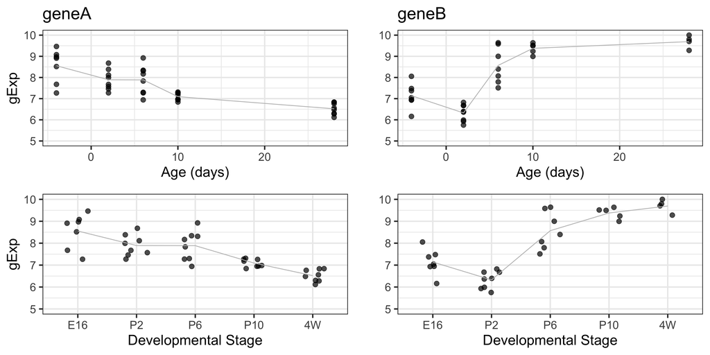

# Linear model with Age as continuous covariate

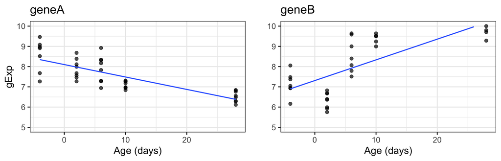

* Linear looks reasonable for gene A, but not so much for gene B

* For now, assume linear is reasonable

# Plain vanilla linear model (Matrix formulation)

`$$\huge \mathbf{Y = X \boldsymbol\alpha + \boldsymbol\varepsilon}$$`

For 1 continuous/quantitative covariate:

`$$\mathbf{Y} = \begin{bmatrix}
  y_{1} \\
  y_{2} \\
  \vdots \\
  y_{n} \\
\end{bmatrix}, \hspace{1em}
\mathbf{X} = \begin{bmatrix}
  1 & x_{1} \\
  1 & x_{2} \\
  \vdots & \vdots \\
  1 & x_{n} \\
\end{bmatrix}, \hspace{1em}
\boldsymbol\alpha = \begin{bmatrix}
  \alpha_{0} \\
  \alpha_{1} \\
\end{bmatrix}, \hspace{1em}
\boldsymbol\varepsilon=\begin{bmatrix}
  \varepsilon_{1} \\
  \varepsilon_{2} \\
  \vdots \\
  \varepsilon_{n} \\
\end{bmatrix}$$`

* `\(\alpha_0=\)` the intercept (expected value of `\(y\)` when `\(x\)` is equal to zero)

* `\(\alpha_1=\)` the slope (expected change in `\(y\)` for every one-unit increase in `\(x\)`)

`$$\huge \mathbf{Y = X \boldsymbol\alpha + \boldsymbol\varepsilon}$$`

Remember / convince yourself that the matrix algebra does indeed reproduce simple linear regression:
`$$\begin{bmatrix}
  y_{1} \\
  y_{2} \\
  \vdots \\
  y_{n} \\
\end{bmatrix}=\begin{bmatrix}
  1 & x_{1} \\
  1 & x_{2} \\
  \vdots & \vdots \\
  1 & x_{n} \\
\end{bmatrix}\begin{bmatrix}
  \alpha_{0} \\
  \alpha_{1} \\
\end{bmatrix}+\begin{bmatrix}
  \varepsilon_{1} \\
  \varepsilon_{2} \\
  \vdots \\
  \varepsilon_{n} \\
\end{bmatrix}=\begin{bmatrix}
  1*\alpha_0 + x_{1}*\alpha_{1} \\
  1*\alpha_0 + x_{2}*\alpha_{1} \\
   \vdots \\
  1*\alpha_0 + x_{n}*\alpha_{1} \\
\end{bmatrix}+\begin{bmatrix}
  \varepsilon_{1} \\
  \varepsilon_{2} \\
  \vdots \\
  \varepsilon_{n} \\
\end{bmatrix}$$`

`$$=\begin{bmatrix}
  \alpha_0 + x_{1}\alpha_{1} + \varepsilon_{1} \\
  \alpha_0 + x_{2}\alpha_{1} + \varepsilon_{2}\\
   \vdots \\
  \alpha_0 + x_{n}\alpha_{1} + \varepsilon_{n} \\
\end{bmatrix}$$`
`$$\Rightarrow y_i = \alpha_0 + x_i\alpha_1 + \varepsilon_i$$`

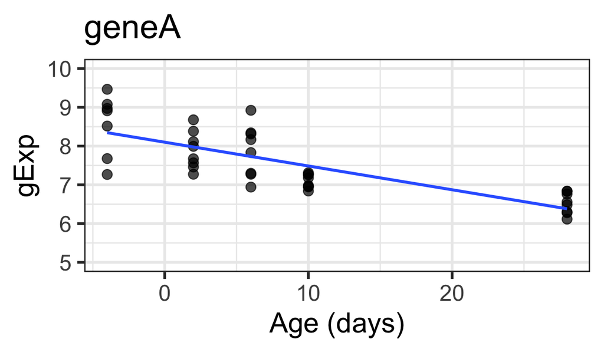

```r
summary(lm(gExp ~ Age, data=devDat %>% filter(gene == "geneA")))
```

```
## Coefficients:
##              Estimate Std. Error t value Pr(>|t|)
*## (Intercept)  8.100126   0.113959   71.08  < 2e-16 ***
## Age         -0.061373   0.008216   -7.47 6.76e-09 ***
## ---
## Signif. codes:  0 '***' 0.001 '**' 0.01 '*' 0.05 '.' 0.1 ' ' 1
##
## Residual standard error: 0.5536 on 37 degrees of freedom
## Multiple R-squared:  0.6013,	Adjusted R-squared:  0.5905
## F-statistic: 55.81 on 1 and 37 DF,  p-value: 6.757e-09
```

`\(H_0: \alpha_0 = 0\)` (whether intercept is zero - usually, not of interest)

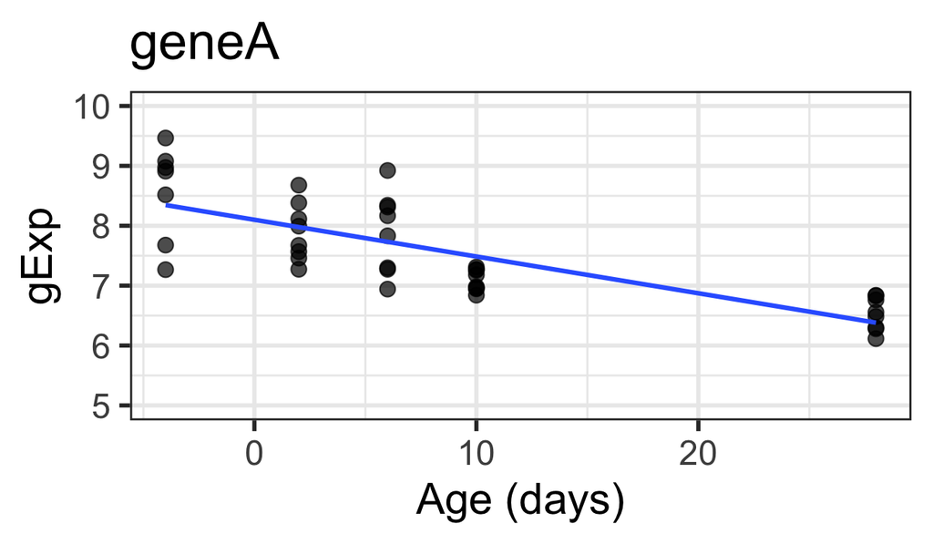

```r
summary(lm(gExp ~ Age, data=devDat %>% filter(gene == "geneA")))
```

```
## Coefficients:
##              Estimate Std. Error t value Pr(>|t|)
## (Intercept)  8.100126   0.113959   71.08  < 2e-16 ***
*## Age         -0.061373   0.008216   -7.47 6.76e-09 ***
## ---
## Signif. codes:  0 '***' 0.001 '**' 0.01 '*' 0.05 '.' 0.1 ' ' 1
##
## Residual standard error: 0.5536 on 37 degrees of freedom
## Multiple R-squared:  0.6013,	Adjusted R-squared:  0.5905
## F-statistic: 55.81 on 1 and 37 DF,  p-value: 6.757e-09
```

`\(H_0: \alpha_1 = 0\)` (tests association between gene expression and age)

# How do we estimate the intercept and slope?

### Is there an *optimal* line?

```r
summary(lm(gExp ~ Age, data=devDat %>% filter(gene == "geneA")))
```

```
## Coefficients:
##              Estimate Std. Error t value Pr(>|t|)
## (Intercept)  8.100126   0.113959   71.08  < 2e-16 ***
## Age         -0.061373   0.008216   -7.47 6.76e-09 ***
## ---
## Signif. codes:  0 '***' 0.001 '**' 0.01 '*' 0.05 '.' 0.1 ' ' 1
##
## Residual standard error: 0.5536 on 37 degrees of freedom
## Multiple R-squared:  0.6013,	Adjusted R-squared:  0.5905
## F-statistic: 55.81 on 1 and 37 DF,  p-value: 6.757e-09
```

# Which one is the **best** line?

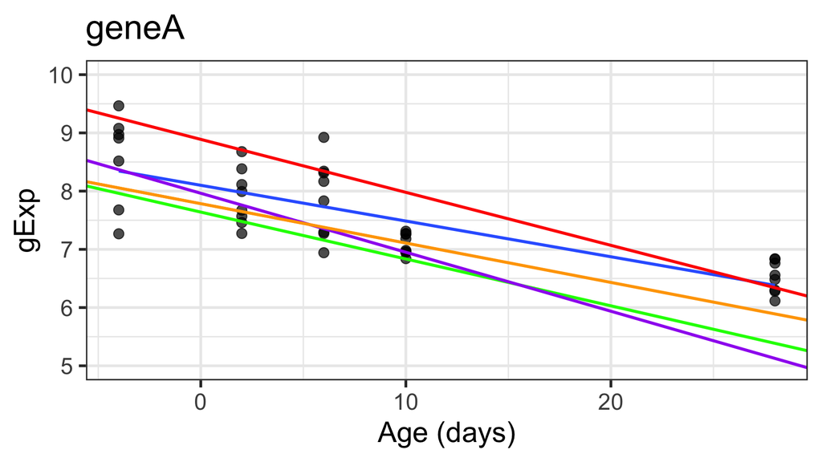

# Ordinary Least Squares

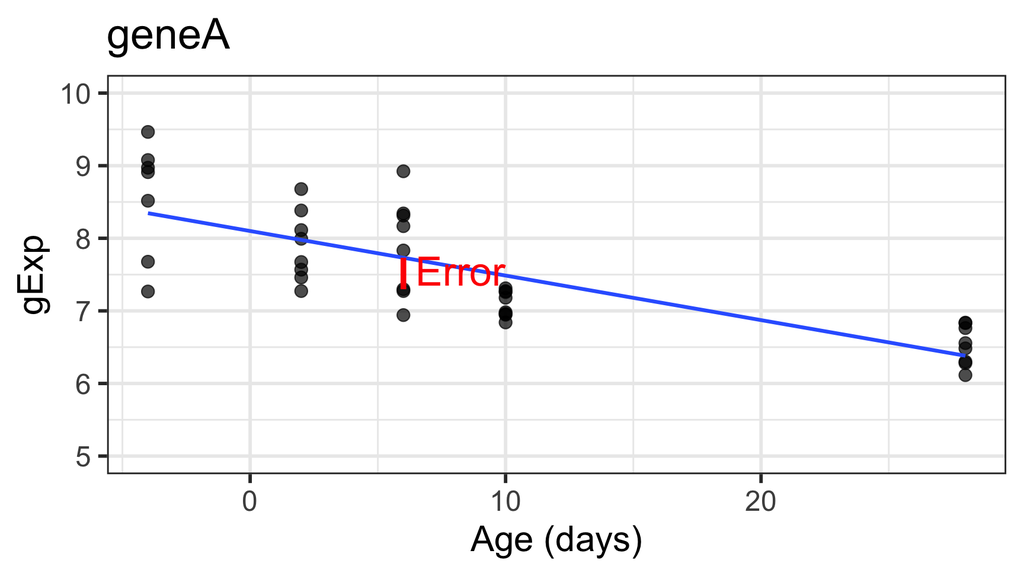

**Ordinary Least Squares (OLS)** regression: parameter estimates minimize the sum of squared errors

**Error**: vertical `\((y)\)` distance between the fitted line and the real observation

# OLS interactive demo

<big>

* Visual representation of the squared errors in OLS: [http://setosa.io/ev/ordinary-least-squares-regression/](http://setosa.io/ev/ordinary-least-squares-regression/)

* The squares of the errors are represented by the square areas in the second plot
  * select different lines by changing the intercept and slope
  * see how the squares of the errors change
  * which line minimizes the sum of these areas? OLS answers this question

* Move a point in the first plot; observe how sensitive the OLS estimation is

# OLS Estimator for Simple Linear Regression (1 covariate)

* Mathematically: `\(\varepsilon_i\)` represents the error
`$$y_i = \alpha_0 + \alpha_1x_i + \varepsilon_i,  i = 1, ..., n$$`

* We want to find the line (i.e. an intercept and slope) such that the sum of squared errors is minimized
`$$S(\alpha_0, \alpha_1)= \sum_{i=1}^n (y_i - \alpha_0 - \alpha_1 x_i)^2$$`

* `\(S(\alpha_0, \alpha_1)\)` is called an *objective function*

* `\(\varepsilon_i=y_i - \alpha_0 - \alpha_1 x_i\)` is the error

# OLS Estimator for Multiple Linear Regression (p covariates)

* Mathematically:
`$$S(\alpha_0, \alpha_1, \alpha_2, ..., \alpha_p) = \sum_{i=1}^n (y_i - \alpha_0 - \alpha_1 x_{1i} - \alpha_2 x_{2i} - ... - \alpha_p x_{pi})^2$$`
`$$=(\mathbf{y}-\mathbf{X}\boldsymbol\alpha)^T(\mathbf{y}-\mathbf{X}\boldsymbol\alpha)$$`

* We need to find values of `\(\boldsymbol\alpha=(\alpha_0, \alpha_1, ..., \alpha_p)\)` that minimize the sum of squares:
`$$\frac{\partial S}{\partial\alpha_0}=\begin{bmatrix}
  \frac{\partial S}{\partial\alpha_0} \\
  \frac{\partial S}{\partial\alpha_1} \\
  \vdots\\
  \frac{\partial S}{\partial\alpha_p} \\
\end{bmatrix}=\begin{bmatrix}
  0 \\
  0 \\
  \vdots\\
  0 \\
\end{bmatrix}$$`

# Properties of OLS regression

**Regression model**: `\(\mathbf{Y = X \boldsymbol\alpha + \boldsymbol\varepsilon}\)`

**OLS estimator**: `\(\hat{\boldsymbol\alpha} =(\mathbf{X}^T\mathbf{X})^{-1}\mathbf{X}^T\mathbf{y}\)`

Assumptions:

1. `\(\boldsymbol\varepsilon\)` are iid (implies constant variance)

2. `\(\boldsymbol\varepsilon\)` have mean zero

If `\(\boldsymbol\varepsilon\)` are iid **Normal**, then OLS estimator is also MLE (Maximum Likelihood Estimator)

**Fitted/predicted values**: `\(\hat{\mathbf{y}} = \mathbf{X} \hat{\boldsymbol\alpha}\)`

`$$= \mathbf{X} (\mathbf{X}^T\mathbf{X})^{-1}\mathbf{X}^T\mathbf{y} = \mathbf{H}\mathbf{y}$$`
where `\(\mathbf{H}=\mathbf{X} (\mathbf{X}^T\mathbf{X})^{-1}\mathbf{X}^T\)` is called the "hat matrix"

# Properties of OLS regression (cont'd)

**Residuals**: (note NOT the same as errors `\(\varepsilon\)`) `$$\hat{\boldsymbol\varepsilon} = \mathbf{y} - \hat{\mathbf{y}} = \mathbf{y} -  \mathbf{X} \hat{\boldsymbol\alpha}$$`

**Estimated error variance**: `$$\hat{\sigma}^2 =  \frac{1}{n-p} \hat{\boldsymbol\varepsilon}^T \hat{\boldsymbol\varepsilon}$$`

**Estimated covariance matrix of** `\(\hat{\boldsymbol\alpha}\)`: `$$\hat{V}(\hat{\boldsymbol\alpha}) = \hat{\sigma}^2(\mathbf{X}^T\mathbf{X})^{-1}$$`

**Estimated standard errors for estimated regression coefficients**:
`\(\hat{se}(\hat{\alpha}_j)\)`, obtained by taking the square root of the diagonal elements of `\(\hat{V}(\hat{\boldsymbol\alpha})\)`

# Inference in Regression (normal iid errors)

<big>

How to test `\(H_0: \alpha_j = 0\)`?

With a *t* statistic!

Under `\(H_0\)`,

`$$\frac{\hat{\alpha_j}}{\hat{se}(\hat{\alpha}_j)} \sim t_{n-p}$$`

So a *p* value is obtained by computing a tail probability for the observed value of `\(\hat{\alpha_j}\)` from a `\(t_{n-p}\)` distribution

# Inference - what if we don't assume Normality of errors?

<big>

How to test `\(H_0: \alpha_j = 0\)`?

With a *t* statistic!

Under `\(H_0\)`,  asymptotically (by CLT)

`$$\frac{\hat{\alpha_j}}{\hat{se}(\hat{\alpha}_j)} \sim t_{n-p}$$`

So a *p* value is obtained by computing a tail probability for the observed value of `\(\hat{\alpha_j}\)` from a `\(t_{n-p}\)` distribution

# Diagnostics: `plot(lm(y~x))`

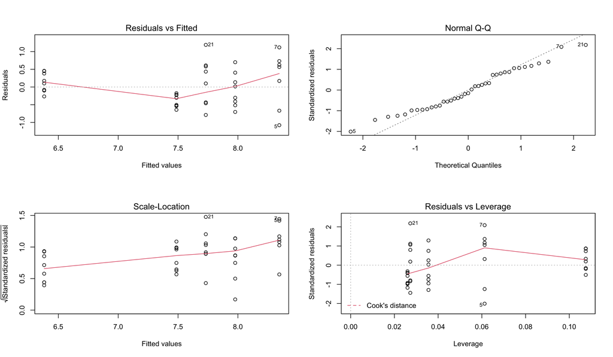

# **Linear** regression

* The nature of the regression function `\(f(x|\boldsymbol\alpha)\)` is one of the defining characteristics of a regression model

* `\(f\)` is linear in `\(\boldsymbol\alpha \Rightarrow\)` **linear model**

* `\(f\)` is not linear in `\(\boldsymbol\alpha \Rightarrow\)` **nonlinear model**

* For example, consider nonlinear parametric regression:

$$ y_i = \frac{1}{1 + e^{(\phi - x_i)/\eta}} + \varepsilon$$

* We just did simple linear regression (a linear model): `\(y_i = \alpha_0 + \alpha_1x_i + \varepsilon_i\)`

* What we could do instead: polynomial regression (also a linear model) `$$y_i = \alpha_0 + \alpha_1x_i + \alpha_2x_i^2 + \varepsilon_i$$`

# Polynomial regression

```r
quadfit <- lm(gExp ~ Age + I(Age^2), data=geneC)
summary(quadfit)
```

```
##
## Call:
## lm(formula = gExp ~ Age + I(Age^2), data = geneC)
##
## Residuals:
##     Min      1Q  Median      3Q     Max
## -1.6250 -0.6437  0.1027  0.4956  1.6997
##
## Coefficients:
##              Estimate Std. Error t value Pr(>|t|)
## (Intercept)  8.482528   0.160882  52.725  < 2e-16 ***
## Age         -0.147335   0.032626  -4.516 6.53e-05 ***
## I(Age^2)     0.005009   0.001164   4.303 0.000123 ***
## ---
## Signif. codes:  0 '***' 0.001 '**' 0.01 '*' 0.05 '.' 0.1 ' ' 1
##
## Residual standard error: 0.7527 on 36 degrees of freedom
## Multiple R-squared:  0.362,	Adjusted R-squared:  0.3265
## F-statistic: 10.21 on 2 and 36 DF,  p-value: 0.000307
```

# Polynomial regression

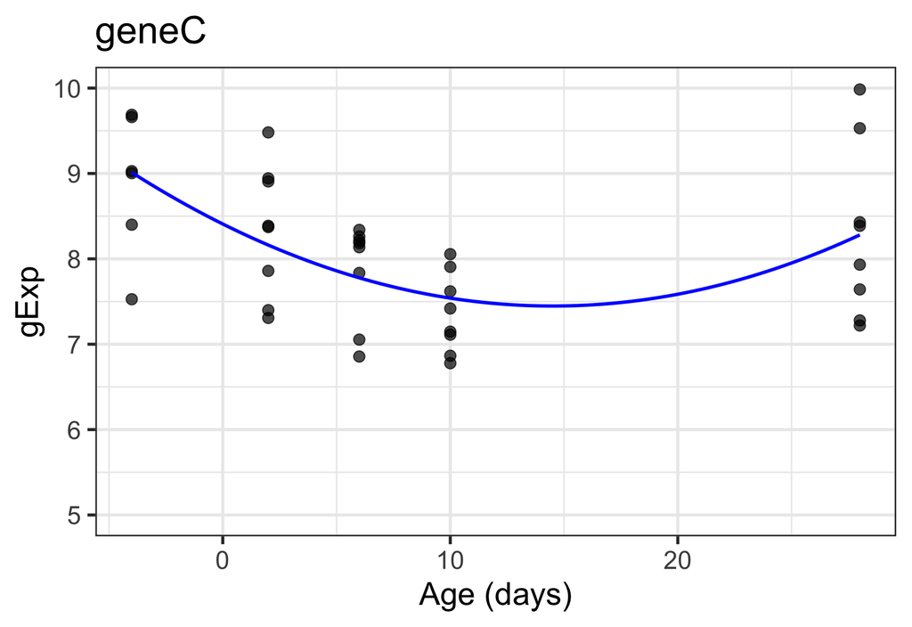

Note that **this is a linear model**, because it is linear in the `\(\alpha_j\)`

# Putting it all together (continuous + categorical variables)

```r
summary(lm(gExp ~ Age*gType, data=devDat %>% filter(gene=="geneA")))
```

```
##
## Call:
## lm(formula = gExp ~ Age * gType, data = devDat %>% filter(gene ==
##     "geneA"))
##
## Residuals:
##      Min       1Q   Median       3Q      Max
## -1.13324 -0.38398 -0.00233  0.31710  1.08867
##
## Coefficients:
##                 Estimate Std. Error t value Pr(>|t|)
## (Intercept)     8.031528   0.156571  51.297  < 2e-16 ***
## Age            -0.066444   0.011419  -5.819 1.34e-06 ***
## gTypeNrlKO      0.142349   0.228278   0.624    0.537
## Age:gTypeNrlKO  0.009853   0.016445   0.599    0.553
## ---
## Signif. codes:  0 '***' 0.001 '**' 0.01 '*' 0.05 '.' 0.1 ' ' 1
##
## Residual standard error: 0.5534 on 35 degrees of freedom
## Multiple R-squared:  0.6231,	Adjusted R-squared:  0.5907
## F-statistic: 19.28 on 3 and 35 DF,  p-value: 1.487e-07
```

# Interaction between continuous and categorical variables

`$$y_{ij} = \alpha_{0} + \tau_{1}x_{ij}^{dummy} + \tau_2 x_{ij}^{Age} + \tau_3 x_{ij}^{dummy}x_{ij}^{Age}$$`

where `\(j \in \{ wt, NrlKO\}\)`, `\(i = 1,2,...,n_j\)`, and `\(x^{dummy}_{ij}\)` is 1 for `\(j=NrlKO\)` and 0 for `\(j=wt\)`

The "intercept" for the knockouts is: `\(\alpha_0 + \tau_1\)`

The slope for the knockouts is: `\(\tau_2 + \tau_3\)`

# Interaction between continuous and categorical variables

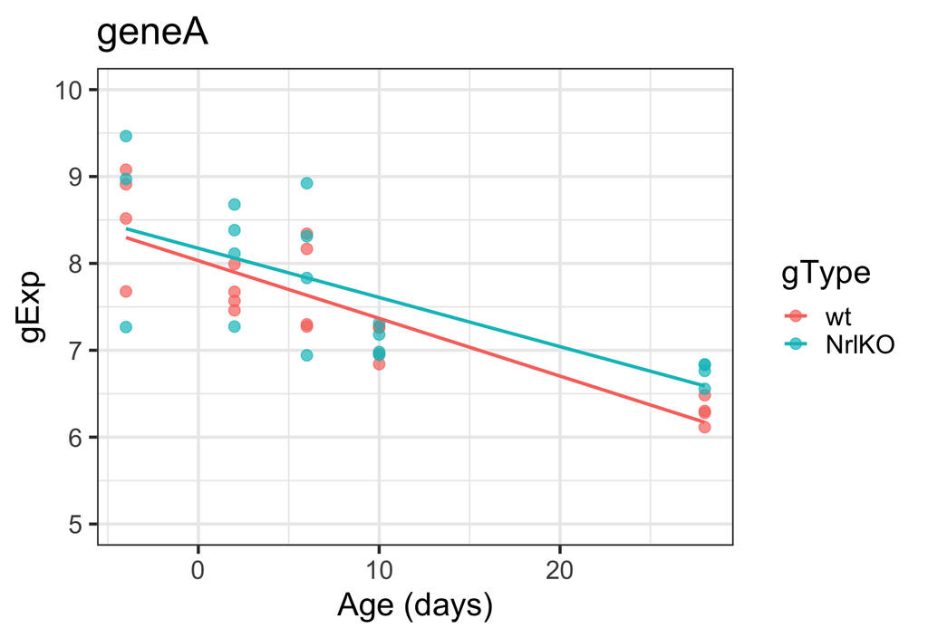

# Interaction between continuous and categorical variables

<big>

```r
summary(lm(gExp ~ Age*gType, data=devDat %>% filter(gene=="geneA")))$coef
```

```
##                    Estimate Std. Error    t value     Pr(>|t|)
## (Intercept)     8.031527929 0.15657060 51.2965249 1.574727e-34
## Age            -0.066443801 0.01141908 -5.8186625 1.338596e-06
## gTypeNrlKO      0.142348659 0.22827782  0.6235764 5.369488e-01
## Age:gTypeNrlKO  0.009852783 0.01644510  0.5991317 5.529437e-01
```

`(Intercept)`: Intercept of wt line

`Age`: slope of wt line

`gTypeNrlKO`: difference in intercepts (KO vs wt)

`Age:gTypeNrlKO`: difference in slopes (KO vs wt)

# Nested models

As always, you can assess the relevance of several terms at once -- such as everything involving genotype -- with an F test

```r
anova(lm(gExp ~ Age*gType, data=devDat %>% filter(gene=="geneA")),
      lm(gExp ~ Age, data=devDat %>% filter(gene=="geneA")))
```

```
## Analysis of Variance Table
##
## Model 1: gExp ~ Age * gType
## Model 2: gExp ~ Age
##   Res.Df    RSS Df Sum of Sq      F Pr(>F)
## 1     35 10.720
## 2     37 11.338 -2  -0.61795 1.0088  0.375
```

It's not clear that genotype affects the intercept or the slope

# F tests in regression

<big>

| Model | Example | # params (df) | RSS |
| ----- | ------- | ------------- | ---- |
| small | gExp ~ Age | `\(p_{small}=2\)` | `\(RSS_{small}\)` |
| big | gExp ~ Age * gType | `\(p_{small}=4\)` | `\(RSS_{big}\)`|

`$$\text{big: } y_{ij}  = \alpha_{0} + \tau_{1}x_{ij}^{dummy} + \tau_2 x_{ij}^{Age} + \tau_3 x_{ij}^{dummy}x_{ij}^{Age}$$`

`$$\text{small: } y_{ij}  = \alpha_{0} + \tau_2 x_{ij}^{Age}$$`

<big>
`$$F = \frac{\frac{RSS_{small}-RSS_{big}}{p_{big}-p_{small}}}{\frac{RSS_{big}}{n-p_{big}}} \sim {\tiny{H_0}} \text{  } F_{p_{big}-p_{small}, n-{p_{big}}}$$`

# Linear regression summary

* linear model framework is extremely general

* one extreme (simple): two-sample common variance t-test

* another extreme (flexible): a polynomial, potentially different for each level of some factor

* dichotomous variable? OK!

* categorical variable? OK!

* quantitative variable? OK!

* various combinations of the above? OK!

* Don't be afraid to build models with more than 1 covariate

# What about the other 29 thousand probesets??

```r
str(prDat)
```

```
## 'data.frame':	29949 obs. of  39 variables:
##  $ Sample_20: num  7.24 9.48 10.01 8.36 8.59 ...
##  $ Sample_21: num  7.41 10.02 10.04 8.37 8.62 ...
##  $ Sample_22: num  7.17 9.85 9.91 8.4 8.52 ...
##  $ Sample_23: num  7.07 10.13 9.91 8.49 8.64 ...
##  $ Sample_16: num  7.38 7.64 8.42 8.36 8.51 ...
##  $ Sample_17: num  7.34 10.03 10.24 8.37 8.89 ...
##  $ Sample_6 : num  7.24 9.71 10.17 8.84 8.54 ...
##  $ Sample_24: num  7.11 9.75 9.39 8.37 8.36 ...
##  $ Sample_25: num  7.19 9.16 10.11 8.2 8.5 ...
##  $ Sample_26: num  7.18 9.49 9.41 8.73 8.39 ...
##  $ Sample_27: num  7.21 8.64 9.43 8.33 8.43 ...
##  $ Sample_14: num  7.09 9.56 9.88 8.57 8.59 ...
##  $ Sample_3 : num  7.16 9.55 9.84 8.33 8.5 ...
##  $ Sample_5 : num  7.08 9.32 9.24 8.3 8.48 ...
```

[output cut: 25 more lines]

# Linear regression of many genes

`$$\huge \mathbf{Y}_g = \mathbf{X}_g \boldsymbol\alpha_g + \boldsymbol\varepsilon_g$$`
<big>

* The g in the subscript reminds us that we'll be fitting a model like this *for each gene g*

* Most of the time, the design matrices `\(\mathbf{X}_g\)` are, in fact, the same for all g. This means, we can just use `\(\mathbf{X}\)`

* Note the residual degrees of freedom `$$d_g = d = n - \text{dimension of } \boldsymbol\alpha = n-p$$`

# Linear regression of many genes (cont'd)

Data model:
`$$\mathbf{Y}_g = \mathbf{X} \boldsymbol\alpha_g + \boldsymbol\varepsilon_g$$`
Unknown error variance:
`$$Var(\boldsymbol\varepsilon_g) = \sigma^2_g$$`
Estimated error variance:
`$$\hat{\sigma}^2_g = s^2_g = \frac{1}{n-p}\hat{\boldsymbol\varepsilon_g}^T\hat{\boldsymbol\varepsilon_g}$$`
Estimated variance of parameter estimates:
`$$\hat{Var}(\hat{\boldsymbol\alpha}) =  (\mathbf{X}^T\mathbf{X})^{-1}  s^2_g = V s^2_g$$`
`\(V\)` is the "unscaled covariance", and is the same for all genes!

### So far, nothing is new - these are the "regular" *t* statistics for gene *g* and parameters *j*:

`$$t_{gj} = \frac{\hat{\alpha}_{gj}}{s_g \sqrt{v_j}} \sim t_d \text{ under } H_0$$`

But there are so many of them!

## Observed (i.e. empirical) issues with the "standard" *t*-test approach for assessing differential expression

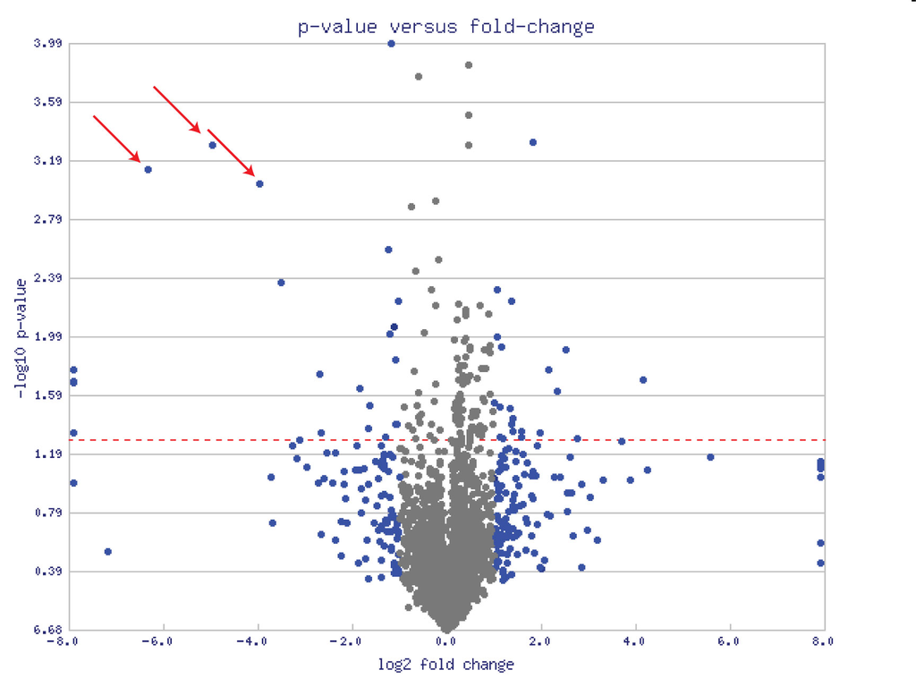

## Observed (i.e. empirical) issues with the "standard" *t*-test approach for assessing differential expression

<big>


Some genes with very small p-values (large -log10 p-values) are not biologically meaningful (small effect size)